# Empirikos.jl: Reproducing REBayes Examples

# Reproducing the REBayes R vignette

The goal of this notebook is to showcase the functionality of the `Empirikos.jl` package by (partially) reproducing results shown in the [REBayes vignette](https://cran.r-project.org/web/packages/REBayes/vignettes/rebayes.pdf).

```julia
using DocumenterQuarto
using Empirikos
using Distributions
using JuMP
using LaTeXStrings
using Plots
using StatsPlots
using Hypatia
using Random
```

```
Precompiling packages...
   1930.5 ms  ✓ QuartoNotebookWorkerLaTeXStringsExt (serial)
  1 dependency successfully precompiled in 2 seconds
Precompiling packages...
   2337.8 ms  ✓ QuartoNotebookWorkerPlotsExt (serial)
  1 dependency successfully precompiled in 2 seconds
```

```julia
gr()
```

```
Plots.GRBackend()
```

## Gaussian Mixture models

### Needles and haystacks

Here we demonstrate the classic “needles in a haystack” scenario from the REBayes vignette. This example simulates data where most observations come from a standard normal distribution ($\mathrm{N}(0,1)$), while a small fraction (10%) come from a shifted normal ($\mathrm{N}(2,1)$).

```julia
zs = rand(MersenneTwister(100), Normal(), 1000) .+ [fill(0,900); fill(2,100)]
zs = sort(zs);
```

In Empirikos.jl, we represent each observation as a `StandardNormalSample` object. This differs from REBayes where you would directly use a vector of observations as input to the `GLmix` function.

The `StandardNormalSample` type encapsulates the observation along with knowledge that it follows a standard normal likelihood (i.e., $Z_i \mid \mu_i \sim \mathrm{N}(\mu_i, 1)$). This type-based approach is a key design feature of Empirikos.jl:

1. It allows the package to know the likelihood structure without additional arguments;
2. It enables multiple dispatch to handle different likelihood models;
3. It maintains a consistent interface across all empirical Bayes problems.

```julia
normal_Zs = StandardNormalSample.(zs)
first(normal_Zs, 3)
```

```
3-element Vector{StandardNormalSample{Float64}}:
 N(-3.1746277553967115; μ, σ=1.0)
 N(-2.990089450782722; μ, σ=1.0)
 N(-2.8559587291548225; μ, σ=1.0)
```

```julia
normal_npmle = fit(NPMLE(DiscretePriorClass(), Hypatia.Optimizer), normal_Zs)
```

[output not shown]

[output cut: 133 more lines]

```
Fitted NPMLE with Hypatia.Optimizer and 𝒢:
DiscretePriorClass | support = -3.1747277553967117:0.030043037229013896:5.808140376078443
```

The NPMLE estimates the mixing distribution nonparametrically, which in this case should identify two mass points - one near 0 and another near 2.

Next, we define our posterior targets - in this case, the posterior means:

```julia
normal_postmean_targets = PosteriorMean.(normal_Zs)
```

```
1000-element Vector{PosteriorMean{StandardNormalSample{Float64}}}:
 𝔼[μ | N(-3.1746277553967115; μ, σ=1.0)]
 𝔼[μ | N(-2.990089450782722; μ, σ=1.0)]
 𝔼[μ | N(-2.8559587291548225; μ, σ=1.0)]
 𝔼[μ | N(-2.7380023441265133; μ, σ=1.0)]
 𝔼[μ | N(-2.724951899176289; μ, σ=1.0)]
 𝔼[μ | N(-2.6950346914636967; μ, σ=1.0)]
 𝔼[μ | N(-2.5584323721075397; μ, σ=1.0)]
 𝔼[μ | N(-2.5305668218766053; μ, σ=1.0)]
 𝔼[μ | N(-2.3632683788658877; μ, σ=1.0)]
 𝔼[μ | N(-2.361941909453861; μ, σ=1.0)]
 ⋮
 𝔼[μ | N(3.4247099212446166; μ, σ=1.0)]
 𝔼[μ | N(3.42836573942505; μ, σ=1.0)]
 𝔼[μ | N(3.835965091861546; μ, σ=1.0)]
 𝔼[μ | N(4.011422275963797; μ, σ=1.0)]
 𝔼[μ | N(4.129379367933984; μ, σ=1.0)]
 𝔼[μ | N(4.1511807079199565; μ, σ=1.0)]
 𝔼[μ | N(4.46857344617616; μ, σ=1.0)]
 𝔼[μ | N(4.538449778609994; μ, σ=1.0)]
 𝔼[μ | N(5.808040376078443; μ, σ=1.0)]
```

The following code creates a three-panel plot showing: 1. The true mixture density 2. The estimated prior distribution (mixing distribution) 3. The posterior mean function (the shrinkage estimator)

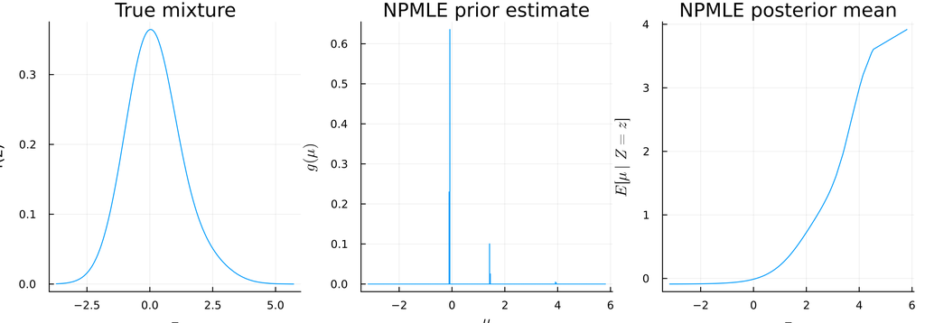

Figure 9.1: Gaussian mixture model analysis. Left: True mixture density. Middle: NPMLE estimated prior. Right: Posterior mean function showing shrinkage effect.

```julia
normal_pl_marginal = plot(marginalize(NormalSample(1.0),
                 DiscreteNonParametric([0.0;2.0], [0.9;0.1])),
                 components=false, label=nothing, xguide="z",
                 yguide = "f(z)",
                 title = "True mixture")

normal_pl_npmle_prior = plot(support(normal_npmle.prior),
                 probs(normal_npmle.prior), seriestype=:sticks,
                 xguide = L"\mu", yguide=L"g(\mu)",
                 title = "NPMLE prior estimate", label=nothing)

normal_pl_posterior_mean = plot(response.(location.(normal_postmean_targets)),
                 normal_postmean_targets.(normal_npmle.prior),
                 label=nothing, title="NPMLE posterior mean",
                 xguide="z", yguide=L"E[\mu \mid Z=z]")

plot(normal_pl_marginal, normal_pl_npmle_prior, normal_pl_posterior_mean,
                 size=(1000,350), layout=(1,3))
```

This plot is similar to what you would see in REBayes but is generated using Empirikos.jl’s object-oriented approach. The posterior mean function (right panel) shows the shrinkage effect: observations are pulled toward the mass points of the estimated prior distribution. The shrinkage is stronger for values close to the mass points and weaker in regions between them.

## Binomial NPMLE

Now we’ll analyze the Tacks dataset using a binomial mixture model. This classic dataset from Beckett and Diaconis involves outcomes from tossing thumbtacks.

```julia
tacks_tbl = Empirikos.Tacks.load_table()
```

```
320-element CSV.File:
 (x = 7, k = 9)
 (x = 4, k = 9)
 (x = 6, k = 9)
 (x = 6, k = 9)
 (x = 6, k = 9)
 (x = 6, k = 9)
 (x = 8, k = 9)
 (x = 6, k = 9)
 (x = 5, k = 9)
 (x = 8, k = 9)
 ⋮
 (x = 6, k = 9)
 (x = 8, k = 9)
 (x = 6, k = 9)
 (x = 9, k = 9)
 (x = 6, k = 9)
 (x = 7, k = 9)
 (x = 6, k = 9)
 (x = 6, k = 9)
 (x = 6, k = 9)
```

We convert the table to a vector of `BinomialSample` objects, where each sample represents the number of successes out of a known number of trials:

```julia
tack_Zs = BinomialSample.(tacks_tbl.x, Int64.(tacks_tbl.k))
```

```
320-element Vector{BinomialSample{Int64, Int64}}:
 ℬ𝒾𝓃(7; p, n=9)
 ℬ𝒾𝓃(4; p, n=9)
 ℬ𝒾𝓃(6; p, n=9)
 ℬ𝒾𝓃(6; p, n=9)
 ℬ𝒾𝓃(6; p, n=9)
 ℬ𝒾𝓃(6; p, n=9)
 ℬ𝒾𝓃(8; p, n=9)
 ℬ𝒾𝓃(6; p, n=9)
 ℬ𝒾𝓃(5; p, n=9)
 ℬ𝒾𝓃(8; p, n=9)
 ⋮
 ℬ𝒾𝓃(6; p, n=9)
 ℬ𝒾𝓃(8; p, n=9)
 ℬ𝒾𝓃(6; p, n=9)
 ℬ𝒾𝓃(9; p, n=9)
 ℬ𝒾𝓃(6; p, n=9)
 ℬ𝒾𝓃(7; p, n=9)
 ℬ𝒾𝓃(6; p, n=9)
 ℬ𝒾𝓃(6; p, n=9)
 ℬ𝒾𝓃(6; p, n=9)
```

In REBayes, a similar analysis would use the `Bmix` function, but here we use our common `fit` interface with NPMLE. The information about the binomial likelihood is provided by the `BinomialSample` type instead, which makes the code more extensible and consistent across different likelihood models.

```julia
tacks_npmle = fit(NPMLE(DiscretePriorClass(), Hypatia.Optimizer), tack_Zs);
```

[output not shown]

[output cut: 23 more lines]

Let’s visualize the estimated prior distribution of success probabilities:

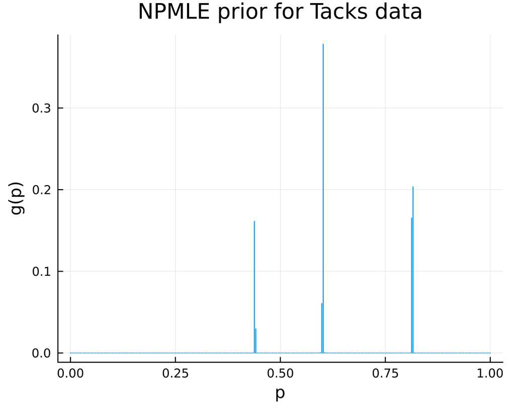

Figure 9.2: Estimated prior distribution for the Tacks dataset showing the probability of a tack landing point-up.

```julia
plot(support(tacks_npmle.prior),
     probs(tacks_npmle.prior),
     seriestype=:sticks,
     xguide = "p",
     yguide = "g(p)",
     size=(500,400),
     label=nothing,
     title="NPMLE prior for Tacks data")
```

The plot shows the estimated distribution of success probabilities for the tacks. The NPMLE identifies several mass points, indicating groups of tacks with different tendencies to land point-up.

## Poisson NPMLE

Finally, we’ll analyze the Norberg insurance claims dataset, which consists of claim counts and exposure times for different occupational groups.

```julia
norberg_tbl = Empirikos.Norberg.load_table()
```

```
72-element CSV.File:
 (OccGroup = 1, Exposure = 3349.02, Death = 16)
 (OccGroup = 2, Exposure = 1394.0, Death = 5)
 (OccGroup = 3, Exposure = 479.81, Death = 0)
 (OccGroup = 4, Exposure = 23.98, Death = 0)
 (OccGroup = 5, Exposure = 11.3, Death = 0)
 (OccGroup = 6, Exposure = 2273.55, Death = 11)
 (OccGroup = 7, Exposure = 179.85, Death = 0)
 (OccGroup = 8, Exposure = 3947.44, Death = 24)
 (OccGroup = 9, Exposure = 4332.56, Death = 9)
 (OccGroup = 10, Exposure = 109.84, Death = 1)
 ⋮
 (OccGroup = 64, Exposure = 826.4, Death = 2)
 (OccGroup = 65, Exposure = 775.19, Death = 1)
 (OccGroup = 66, Exposure = 634.16, Death = 2)
 (OccGroup = 67, Exposure = 2293.45, Death = 6)
 (OccGroup = 68, Exposure = 942.03, Death = 4)
 (OccGroup = 69, Exposure = 232.31, Death = 2)
 (OccGroup = 70, Exposure = 37.08, Death = 0)
 (OccGroup = 71, Exposure = 233.25, Death = 0)
 (OccGroup = 72, Exposure = 39.52, Death = 0)
```

We convert the data to `PoissonSample` objects. Each sample captures both the count (death) and the exposure time:

```julia
norberg_Zs = Empirikos.PoissonSample.(norberg_tbl.Death, norberg_tbl.Exposure ./ 344);
```

Let’s examine the range of claim rates:

```julia
extrema(response.(norberg_Zs) ./ nuisance_parameter.(norberg_Zs))
```

```
(0.0, 8.888314708352173)
```

And check how many groups had zero claims:

```julia
sum(response.(norberg_Zs) .== 0) # how many zeros in the samples?
```

```
23
```

Now we fit the NPMLE with a finer grid of 1000 points:

```julia
norberg_npmle = fit(NPMLE(DiscretePriorClass(),
                    Hypatia.Optimizer;
                    prior_grid_length=1000),
                    norberg_Zs);
```

[output not shown]

[output cut: 43 more lines]

In REBayes, this would be accomplished with the `Pmix` function with exposure arguments, but our approach provides a unified interface with the type system handling the exposure information.

Let’s visualize the results:

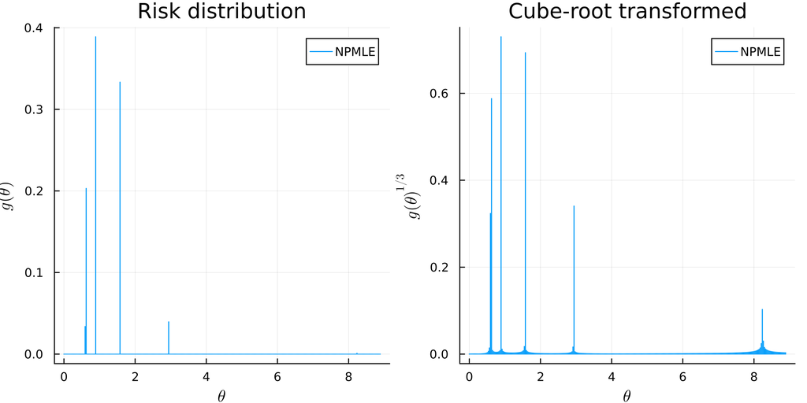

Figure 9.3: Estimated risk distribution for insurance claims data. Left: Original scale. Right: Cube-root transformed to better visualize smaller masses.

```julia
pl = plot(
        plot(support(norberg_npmle.prior),
            probs(norberg_npmle.prior)./sum(probs(norberg_npmle.prior)),
            seriestype=:sticks,
            xguide = L"\theta",
            yguide = L"g(\theta)",
            legend=:topright,
            label="NPMLE",
            title="Risk distribution"),
        plot(support(norberg_npmle.prior),
            (probs(norberg_npmle.prior) ./ sum(probs(norberg_npmle.prior))).^(1/3),
            seriestype=:sticks,
            xguide = L"\theta",
            yguide = L"g(\theta)^{1/3}",
            legend=:topright,
            label="NPMLE",
            title="Cube-root transformed"),
            size=(800,400)
        )
```

The left panel shows the estimated risk distribution, while the right panel shows the cube-root transformation to better visualize smaller masses. Similar to the REBayes analysis, we can see evidence of groups with particularly high risk (around θ=8), which would be difficult to capture with a parametric approach.

Finally, we compute the posterior means for each group:

```julia
norgberg_postmean_npmle = (PosteriorMean.(norberg_Zs)).(norberg_npmle.prior)
```

```
72-element Vector{Float64}:
 1.5164975842807031
 1.1477304065340155
 0.8900678377324209
 1.1229084012736283
 1.1343002517798095
 1.4664836976424256
 1.0164761801730355
 1.6494796560566145
 0.7913509960409266
 1.27130161215924
 ⋮
 0.9955904920651086
 0.8996424245363493
 1.0851109079910963
 0.9348278204497492
 1.2292844652745618
 1.3854935457953732
 1.111789060840034
 0.9884559784124958
 1.109783055647462
```

These values represent the empirical Bayes credibility estimates for each occupation group’s risk factor. In insurance terminology, these would be used to set premiums that reflect both the overall portfolio patterns and each group’s specific experience.

```julia
# Display the mean posterior estimate
mean(norgberg_postmean_npmle)
```

```
1.1450622515838351
```

This mean value represents the overall risk level across all occupational groups after empirical Bayes adjustment.